# Sanket Project

Sanket

2024-11-25

```r
options(repos = c(CRAN = "https://cloud.r-project.org"))

#install.packages
library(readxl)
library(knitr)
library(TTR)
library(dplyr)
library(ggplot2)
library(forecast)
library(tidyverse)
library(tseries)

# Load the Excel file
data  <- read.csv("C:/Users/Sanket Khamkar/Downloads/Data Dictionary_Sanket.csv")
names(data)
```

```
## [1] "Year_Quarter"     "Birth.rate.group" "Indicator"        "Group"
## [5] "FertilityRate"    "Unit"             "MortalityRate"
```

```r
knitr::kable(data)
```

| Year_Quarter | Birth.rate.group | Indicator | Group | FertilityRate | Unit | MortalityRate |
| --- | --- | --- | --- | --- | --- | --- |
| 2024 Q1 | Age-specific Birth Rates | 10-14 years | All races and origins | 0.2 | per 1,000 population | 0.008 |
| 2024 Q1 | Age-specific Birth Rates | 10-14 years | Hispanic | 0.3 | per 1,000 population | 0.012 |
| 2024 Q1 | Age-specific Birth Rates | 10-14 years | Non-Hispanic Black | 0.3 | per 1,000 population | 0.012 |
| 2024 Q1 | Age-specific Birth Rates | 10-14 years | Non-Hispanic White | 0.1 | per 1,000 population | 0.004 |
| 2024 Q1 | Age-specific Birth Rates | 15-19 years | All races and origins | 13.2 | per 1,000 population | 0.528 |
| 2024 Q1 | Age-specific Birth Rates | 15-19 years | Hispanic | 21.3 | per 1,000 population | 0.852 |
| 2024 Q1 | Age-specific Birth Rates | 15-19 years | Non-Hispanic Black | 19.1 | per 1,000 population | 0.764 |
| 2024 Q1 | Age-specific Birth Rates | 15-19 years | Non-Hispanic White | 8.5 | per 1,000 population | 0.340 |
| 2024 Q1 | Age-specific Birth Rates | 20-24 years | All races and origins | 55.1 | per 1,000 population | 2.204 |
| 2024 Q1 | Age-specific Birth Rates | 20-24 years | Hispanic | 78.3 | per 1,000 population | 3.132 |
| 2024 Q1 | Age-specific Birth Rates | 20-24 years | Non-Hispanic Black | 65.3 | per 1,000 population | 2.612 |
| 2024 Q1 | Age-specific Birth Rates | 20-24 years | Non-Hispanic White | 46.0 | per 1,000 population | 1.840 |
| 2024 Q1 | Age-specific Birth Rates | 25-29 years | All races and origins | 91.1 | per 1,000 population | 3.644 |
| 2024 Q1 | Age-specific Birth Rates | 25-29 years | Hispanic | 112.5 | per 1,000 population | 4.500 |
| 2024 Q1 | Age-specific Birth Rates | 25-29 years | Non-Hispanic Black | 84.2 | per 1,000 population | 3.368 |
| 2024 Q1 | Age-specific Birth Rates | 25-29 years | Non-Hispanic White | 89.2 | per 1,000 population | 3.568 |
| 2024 Q1 | Age-specific Birth Rates | 30-34 years | All races and origins | 95.6 | per 1,000 population | 3.824 |
| 2024 Q1 | Age-specific Birth Rates | 30-34 years | Hispanic | 102.4 | per 1,000 population | 4.096 |
| 2024 Q1 | Age-specific Birth Rates | 30-34 years | Non-Hispanic Black | 76.4 | per 1,000 population | 3.056 |
| 2024 Q1 | Age-specific Birth Rates | 30-34 years | Non-Hispanic White | 98.3 | per 1,000 population | 3.932 |
| 2024 Q1 | Age-specific Birth Rates | 35-39 years | All races and origins | 55.0 | per 1,000 population | 2.200 |
| 2024 Q1 | Age-specific Birth Rates | 35-39 years | Hispanic | 60.2 | per 1,000 population | 2.408 |
| 2024 Q1 | Age-specific Birth Rates | 35-39 years | Non-Hispanic Black | 49.7 | per 1,000 population | 1.988 |
| 2024 Q1 | Age-specific Birth Rates | 35-39 years | Non-Hispanic White | 52.6 | per 1,000 population | 2.104 |
| 2024 Q1 | Age-specific Birth Rates | 40-44 years | All races and origins | 12.8 | per 1,000 population | 0.512 |
| 2024 Q1 | Age-specific Birth Rates | 40-44 years | Hispanic | 15.8 | per 1,000 population | 0.632 |
| 2024 Q1 | Age-specific Birth Rates | 40-44 years | Non-Hispanic Black | 14.1 | per 1,000 population | 0.564 |
| 2024 Q1 | Age-specific Birth Rates | 40-44 years | Non-Hispanic White | 10.7 | per 1,000 population | 0.428 |
| 2024 Q1 | Age-specific Birth Rates | 45+ years | All races and origins | 1.1 | per 1,000 population | 0.044 |
| 2024 Q1 | Age-specific Birth Rates | 45+ years | Hispanic | 1.1 | per 1,000 population | 0.044 |

[output cut: 438 more lines]

```r
head(data)
```

```
##   Year_Quarter         Birth.rate.group   Indicator                 Group
## 1      2024 Q1 Age-specific Birth Rates 10-14 years All races and origins
## 2      2024 Q1 Age-specific Birth Rates 10-14 years              Hispanic
## 3      2024 Q1 Age-specific Birth Rates 10-14 years    Non-Hispanic Black
## 4      2024 Q1 Age-specific Birth Rates 10-14 years    Non-Hispanic White
## 5      2024 Q1 Age-specific Birth Rates 15-19 years All races and origins
## 6      2024 Q1 Age-specific Birth Rates 15-19 years              Hispanic
##   FertilityRate                 Unit MortalityRate
## 1           0.2 per 1,000 population         0.008
## 2           0.3 per 1,000 population         0.012
## 3           0.3 per 1,000 population         0.012
## 4           0.1 per 1,000 population         0.004
## 5          13.2 per 1,000 population         0.528
## 6          21.3 per 1,000 population         0.852
```

```r
# Function to convert 'Year_Quarter' to start date for each quarter
convert_quarter_to_date <- function(quarter) {
  if (is.na(quarter)) {
    return(NA)  # Return NA if quarter is missing
  }
  year <- as.numeric(substr(quarter, 1, 4))
  q <- substr(quarter, 6, 7)

  if (q == "Q1") {
    return(as.Date(paste0(year, "-01-01")))
  } else if (q == "Q2") {
    return(as.Date(paste0(year, "-04-01")))
  } else if (q == "Q3") {
    return(as.Date(paste0(year, "-07-01")))
  } else if (q == "Q4") {
    return(as.Date(paste0(year, "-10-01")))
  } else {
    return(NA)  # Return NA if the quarter is not in a recognized format
  }
}

# Apply the conversion to the 'Year Quarter' column
data$Date <- sapply(data$`Year_Quarter`, convert_quarter_to_date)

# Convert the 'Rate' column to numeric and clean up the data
data$FertilityRate <- as.numeric(data$FertilityRate)
data <- data[!is.na(data$Date) & !is.na(data$FertilityRate), ]
data$MortalityRate <- as.numeric(data$MortalityRate)
data <- data[!is.na(data$Date) & !is.na(data$MortalityRate), ]
# Ensure Date column is a factor (or convert as needed)
data$Date <- as.factor(data$Date)
```

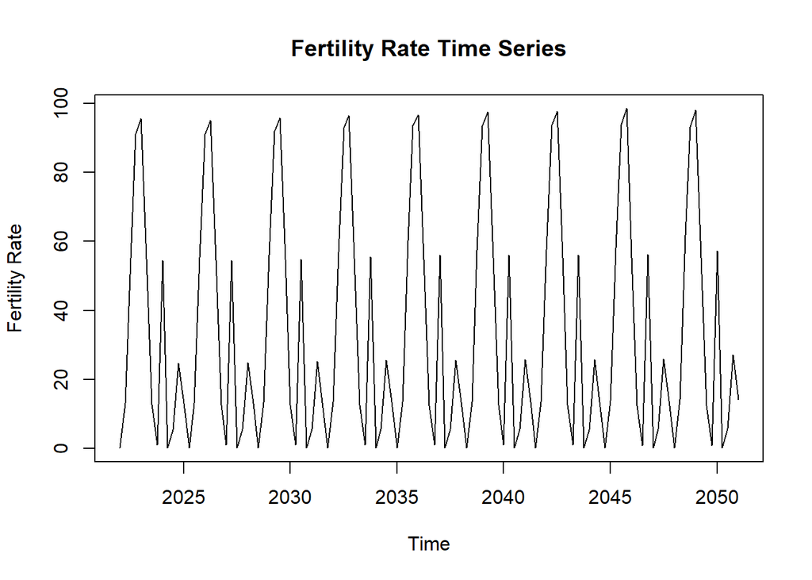

```r
# Filter for 'All races and origins' and set time series
data_filtered <- subset(data, Group == "All races and origins")
ts_data <- ts(data_filtered$FertilityRate, start = c(2022, 1), frequency = 4)

# Plot the time series
plot(ts_data , main = "Fertility Rate Time Series", ylab = "Fertility Rate", xlab = "Time")
```

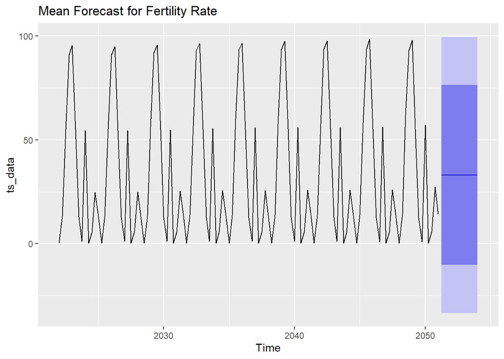

```r
#Mean forecast
mean_model <- meanf(ts_data, h = 12)

# Plot the forecast
autoplot(mean_model) + ggtitle("Mean Forecast for Fertility Rate")
```

```r
forecast(mean_model)
```

```
##         Point Forecast     Lo 80    Hi 80     Lo 95    Hi 95
## 2051 Q2        33.1094 -10.15788 76.37669 -33.37894 99.59774
## 2051 Q3        33.1094 -10.15788 76.37669 -33.37894 99.59774
## 2051 Q4        33.1094 -10.15788 76.37669 -33.37894 99.59774
## 2052 Q1        33.1094 -10.15788 76.37669 -33.37894 99.59774
## 2052 Q2        33.1094 -10.15788 76.37669 -33.37894 99.59774
## 2052 Q3        33.1094 -10.15788 76.37669 -33.37894 99.59774
## 2052 Q4        33.1094 -10.15788 76.37669 -33.37894 99.59774
## 2053 Q1        33.1094 -10.15788 76.37669 -33.37894 99.59774
## 2053 Q2        33.1094 -10.15788 76.37669 -33.37894 99.59774
## 2053 Q3        33.1094 -10.15788 76.37669 -33.37894 99.59774
## 2053 Q4        33.1094 -10.15788 76.37669 -33.37894 99.59774
## 2054 Q1        33.1094 -10.15788 76.37669 -33.37894 99.59774
```

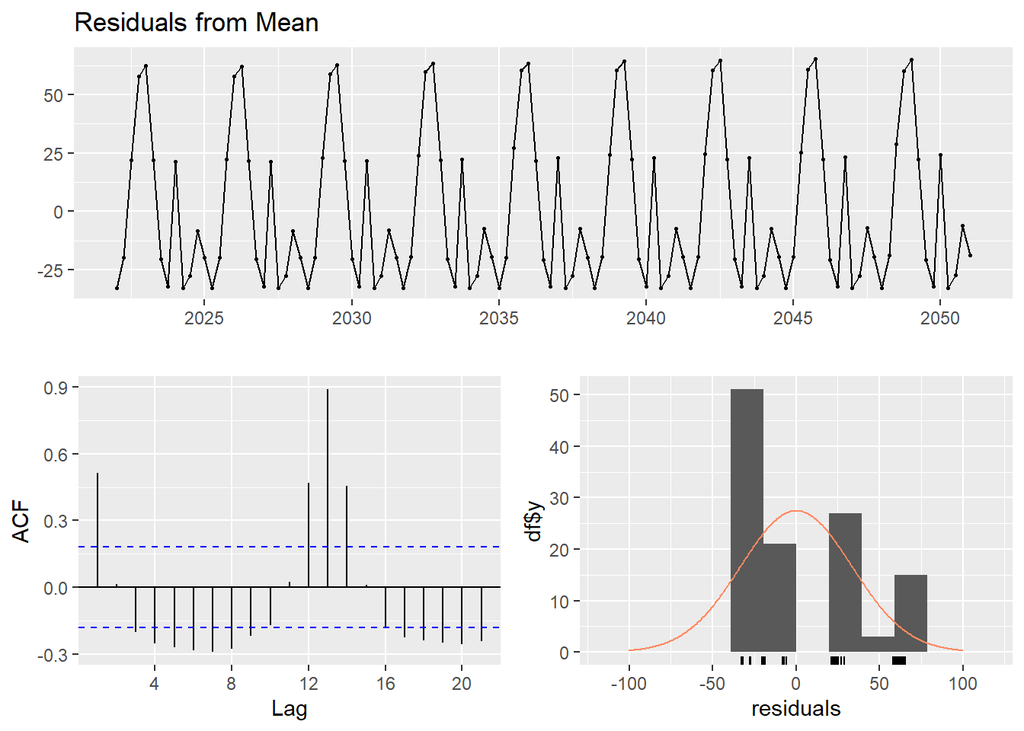

```
##
##  Ljung-Box test
##
## data:  Residuals from Mean
## Q* = 84.168, df = 8, p-value = 7.105e-15
##
## Model df: 0.   Total lags used: 8
```

```r
# Residual Analysis
checkresiduals(mean_model)
```

Uses the average of past data as the forecast. Best for stationary data without trends or seasonality. Residuals should be random, indicating that the mean is a suitable representation.

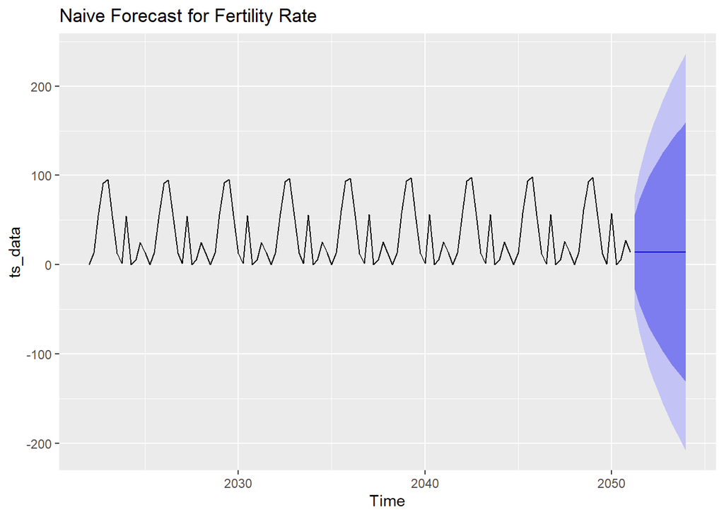

```r
#Naive forecast
naive_model <- naive(ts_data, h = 12)

# Plot the forecast
autoplot(naive_model) + ggtitle("Naive Forecast for Fertility Rate")
```

```r
forecast(naive_model)
```

```
##         Point Forecast      Lo 80     Hi 80      Lo 95    Hi 95
## 2051 Q2           14.3  -27.69722  56.29722  -49.92920  78.5292
## 2051 Q3           14.3  -45.09304  73.69304  -76.53381 105.1338
## 2051 Q4           14.3  -58.44132  87.04132  -96.94824 125.5482
## 2052 Q1           14.3  -69.69444  98.29444 -114.15841 142.7584
## 2052 Q2           14.3  -79.60864 108.20864 -129.32087 157.9209
## 2052 Q3           14.3  -88.57176 117.17176 -143.02878 171.6288
## 2052 Q4           14.3  -96.81420 125.41420 -155.63450 184.2345
## 2053 Q1           14.3 -104.48607 133.08607 -167.36762 195.9676
## 2053 Q2           14.3 -111.69166 140.29166 -178.38761 206.9876
## 2053 Q3           14.3 -118.50687 147.10687 -188.81058 217.4106
## 2053 Q4           14.3 -124.98902 153.58902 -198.72417 227.3242
## 2054 Q1           14.3 -131.18263 159.78263 -208.19649 236.7965
```

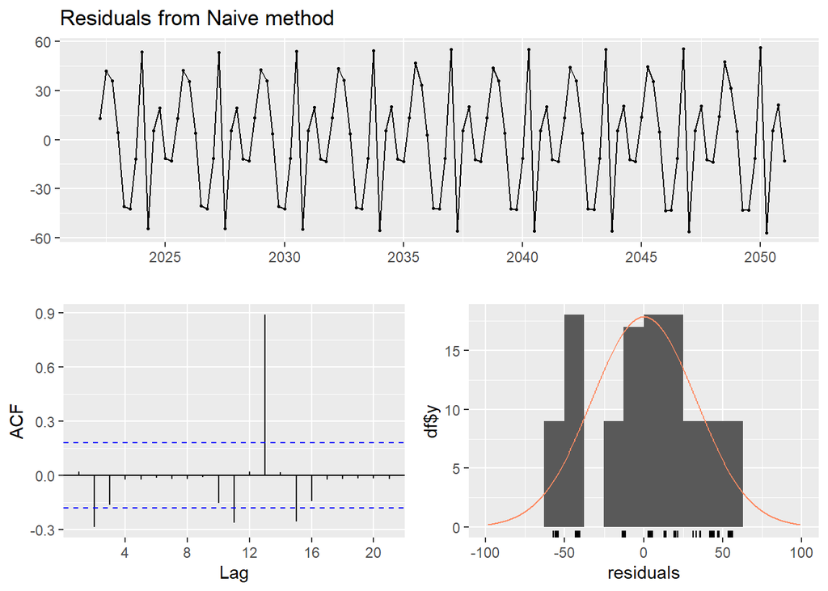

```
##
##  Ljung-Box test
##
## data:  Residuals from Naive method
## Q* = 13.413, df = 8, p-value = 0.0984
##
## Model df: 0.   Total lags used: 8
```

```r
# Residual Analysis
checkresiduals(naive_model)
```

Suitable for short-term forecasts where the most recent observation is the best predictor. Ideal for data without trends or seasonality. Random residuals indicate a good fit.

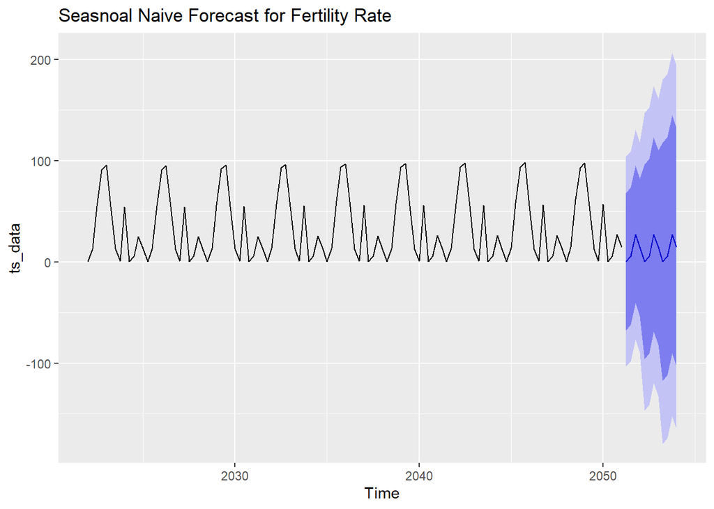

```r
#Seasonal Naive forecast
snaive_forecast <- snaive(ts_data,  h = 12)
# Plot the forecast
autoplot(snaive_forecast) + ggtitle("Seasnoal Naive Forecast for Fertility Rate")
```

```r
forecast(snaive_forecast)
```

```
##         Point Forecast      Lo 80     Hi 80      Lo 95    Hi 95
## 2051 Q2            0.2  -67.69032  68.09032 -103.62928 104.0293
## 2051 Q3            5.8  -62.09032  73.69032  -98.02928 109.6293
## 2051 Q4           27.2  -40.69032  95.09032  -76.62928 131.0293
## 2052 Q1           14.3  -53.59032  82.19032  -89.52928 118.1293
## 2052 Q2            0.2  -95.81141  96.21141 -146.63678 147.0368
## 2052 Q3            5.8  -90.21141 101.81141 -141.03678 152.6368
## 2052 Q4           27.2  -68.81141 123.21141 -119.63678 174.0368
## 2053 Q1           14.3  -81.71141 110.31141 -132.53678 161.1368
## 2053 Q2            0.2 -117.38948 117.78948 -179.63759 180.0376
## 2053 Q3            5.8 -111.78948 123.38948 -174.03759 185.6376
## 2053 Q4           27.2  -90.38948 144.78948 -152.63759 207.0376
## 2054 Q1           14.3 -103.28948 131.88948 -165.53759 194.1376
```

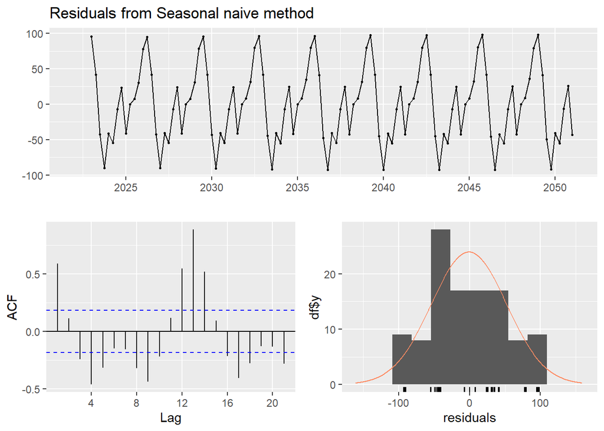

```
##
##  Ljung-Box test
##
## data:  Residuals from Seasonal naive method
## Q* = 105.04, df = 8, p-value < 2.2e-16
##
## Model df: 0.   Total lags used: 8
```

```r
# Residual Analysis
checkresiduals(snaive_forecast)
```

Suitable for data with strong seasonal patterns. It uses the value from the same season in the previous cycle. Residuals should be random if seasonality is captured effectively.

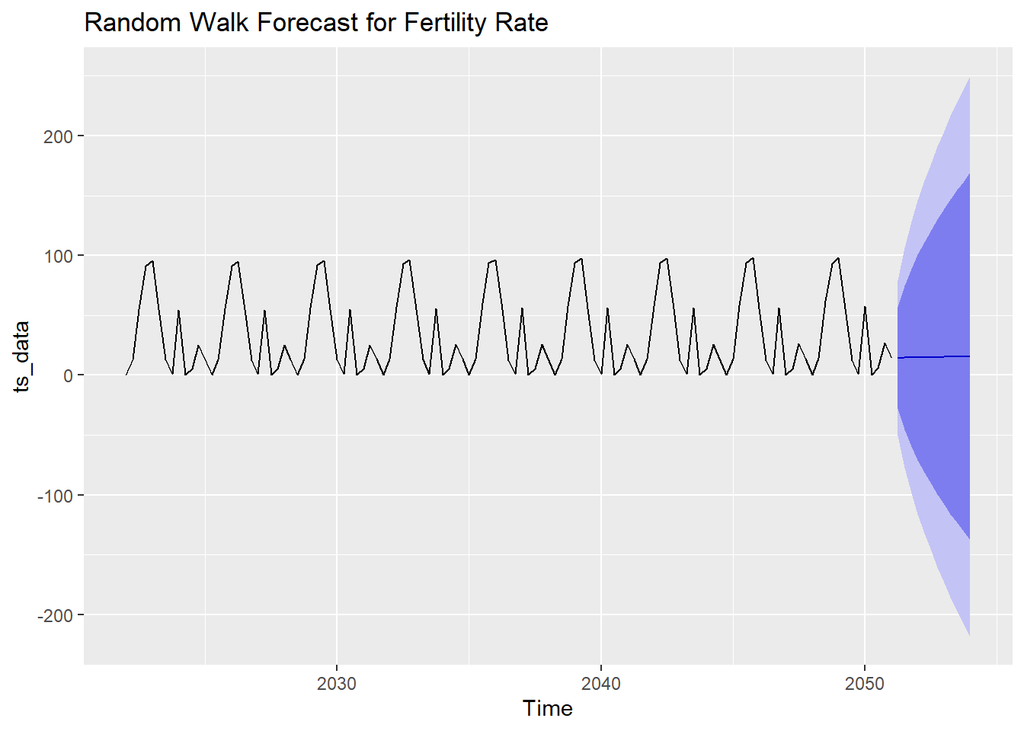

```r
#Random walk forecast
rwf_forecast <- rwf(ts_data,h = 12)
rwf_forecast <- rwf(ts_data,h = 12, drift=TRUE)
autoplot(rwf_forecast) + ggtitle("Random Walk Forecast for Fertility Rate")
```

```r
forecast(rwf_forecast)
```

```
##         Point Forecast      Lo 80     Hi 80      Lo 95     Hi 95
## 2051 Q2       14.42155  -27.93900  56.78210  -50.36331  79.20642
## 2051 Q3       14.54310  -45.61922  74.70543  -77.46724 106.55344
## 2051 Q4       14.66466  -59.33041  88.65972  -98.50103 127.83034
## 2052 Q1       14.78621  -71.01418 100.58659 -116.43416 146.00657
## 2052 Q2       14.90776  -81.41886 111.23438 -132.41109 162.22661
## 2052 Q3       15.02931  -90.92635 120.98497 -147.01589 177.07451
## 2052 Q4       15.15086  -99.76241 130.06414 -160.59383 190.89555
## 2053 Q1       15.27241 -108.07341 138.61824 -173.36875 203.91358
## 2053 Q2       15.39397 -115.96051 146.74844 -185.49538 216.28331
## 2053 Q3       15.51552 -123.49700 154.52803 -197.08578 228.11681
## 2053 Q4       15.63707 -130.73790 162.01204 -208.22413 239.49827
## 2054 Q1       15.75862 -137.72578 169.24302 -218.97551 250.49275
```

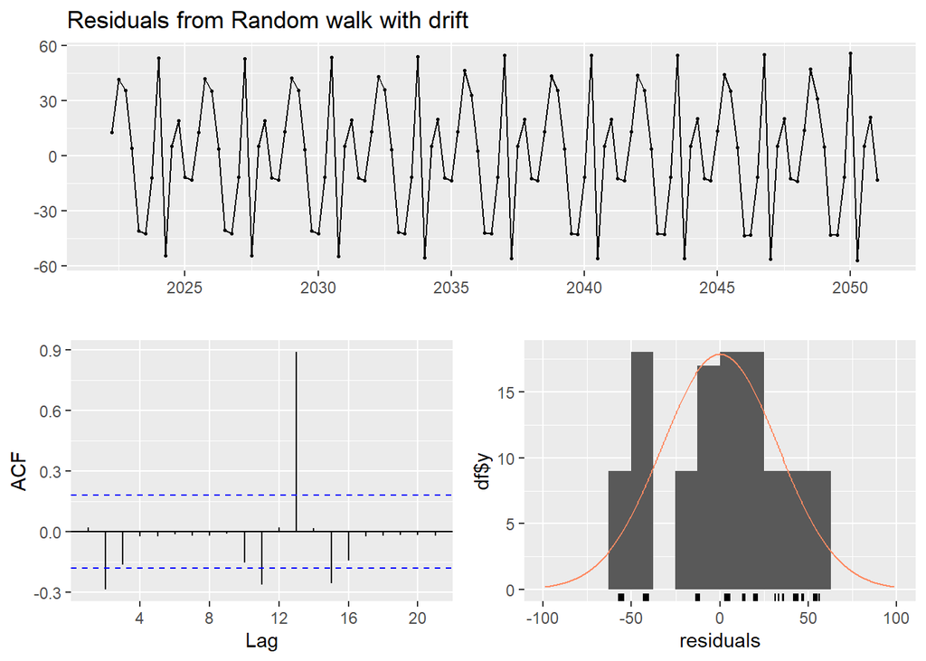

```
##
##  Ljung-Box test
##
## data:  Residuals from Random walk with drift
## Q* = 13.413, df = 8, p-value = 0.0984
##
## Model df: 0.   Total lags used: 8
```

```r
# Residual Analysis
checkresiduals(rwf_forecast)
```

Useful for data that has a persistent random walk behavior, sometimes with a drift representing a trend. Residuals should be random if the drift captures the trend accurately.

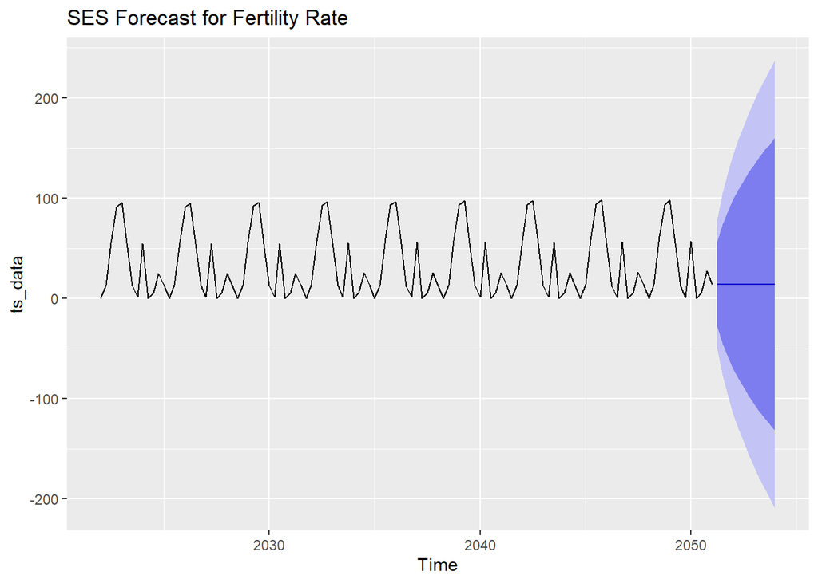

```r
# Simple Exponential Smoothing
ses_model <- ses(ts_data, h = 12)

# Plot the forecast
autoplot(ses_model) + ggtitle("SES Forecast for Fertility Rate")
```

```r
forecast(ses_model)
```

```
##         Point Forecast      Lo 80     Hi 80      Lo 95     Hi 95
## 2051 Q2       14.30129  -27.87821  56.48079  -50.20669  78.80927
## 2051 Q3       14.30129  -45.34655  73.94913  -76.92221 105.52479
## 2051 Q4       14.30129  -58.75088  87.35346  -97.42236 126.02494
## 2052 Q1       14.30129  -70.05138  98.65396 -114.70499 143.30757
## 2052 Q2       14.30129  -80.00739 108.60997 -129.93140 158.53398
## 2052 Q3       14.30129  -89.00835 117.61093 -143.69717 172.29975
## 2052 Q4       14.30129  -97.28561 125.88819 -156.35615 184.95873
## 2053 Q1       14.30129 -104.98991 133.59249 -168.13886 196.74144
## 2053 Q2       14.30129 -112.22596 140.82854 -179.20544 207.80802
## 2053 Q3       14.30129 -119.07000 147.67258 -189.67249 218.27507
## 2053 Q4       14.30129 -125.57957 154.18215 -199.62802 228.23060
## 2054 Q1       14.30129 -131.79939 160.40197 -209.14042 237.74300
```

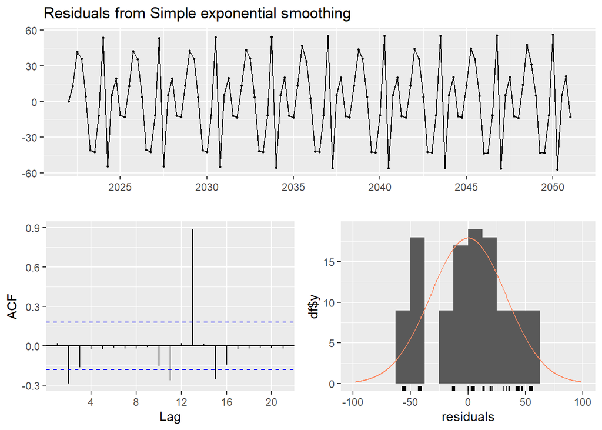

```
##
##  Ljung-Box test
##
## data:  Residuals from Simple exponential smoothing
## Q* = 13.53, df = 8, p-value = 0.09486
##
## Model df: 0.   Total lags used: 8
```

```r
# Residual Analysis
checkresiduals(ses_model)
```

Works well for level data without trend or seasonality. Residuals should resemble white noise if the model fits correctly.

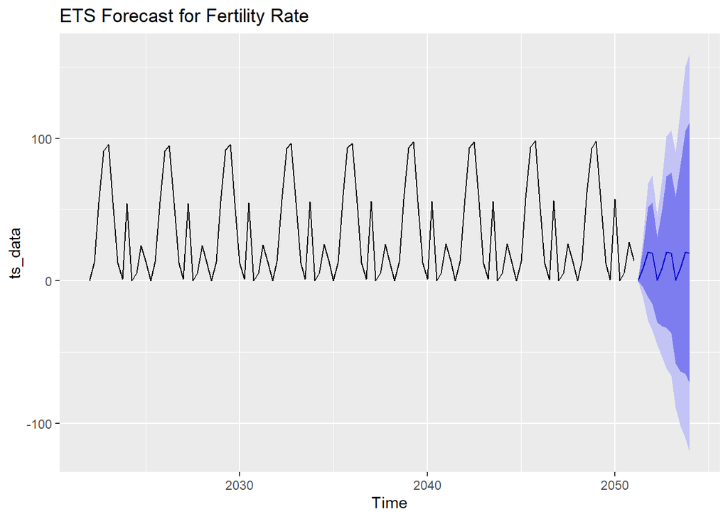

```r
# Fit an ETS model
ets_model <- ets(ts_data)

# Forecast the next 12 months
ets_forecast <- forecast(ets_model, h = 12)

# Plot the forecast
autoplot(ets_forecast) + ggtitle("ETS Forecast for Fertility Rate")
```

```r
forecast(ets_forecast)
```

```
##         Point Forecast       Lo 80      Hi 80        Lo 95      Hi 95
## 2051 Q2      0.6226648  -0.3158727   1.561202   -0.8127045   2.058034
## 2051 Q3      9.0867881  -4.6207880  22.794364  -11.8771405  30.050717
## 2051 Q4     20.1410892 -11.2753693  51.557548  -27.9062379  68.188416
## 2052 Q1     19.6087475 -16.0538481  55.271343  -34.9324858  74.149981
## 2052 Q2      0.6226648 -29.0710315  30.316361  -44.7899248  46.035255
## 2052 Q3      9.0867881 -31.6348488  49.808425  -53.1915812  71.365158
## 2052 Q4     20.1410892 -33.0619302  73.344109  -61.2259074 101.508086
## 2053 Q1     19.6087475 -36.6891037  75.906599  -66.4913860 105.708881
## 2053 Q2      0.6226648 -58.0596023  59.304932  -89.1241180  90.369448
## 2053 Q3      9.0867881 -63.4627511  81.636327 -101.8681573 120.041734
## 2053 Q4     20.1410892 -65.0351518 105.317330 -110.1247302 150.406909
## 2054 Q1     19.6087475 -71.8948485 111.112344 -120.3339262 159.551421
```

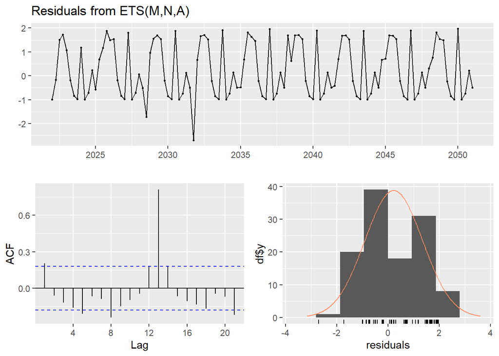

```
##
##  Ljung-Box test
##
## data:  Residuals from ETS(M,N,A)
## Q* = 24.904, df = 8, p-value = 0.001614
##
## Model df: 0.   Total lags used: 8
```

```r
# Residual Analysis
checkresiduals(ets_forecast)
```

Captures level, trend, and seasonality effectively. Residuals should be random and without autocorrelation to indicate a good model fit.

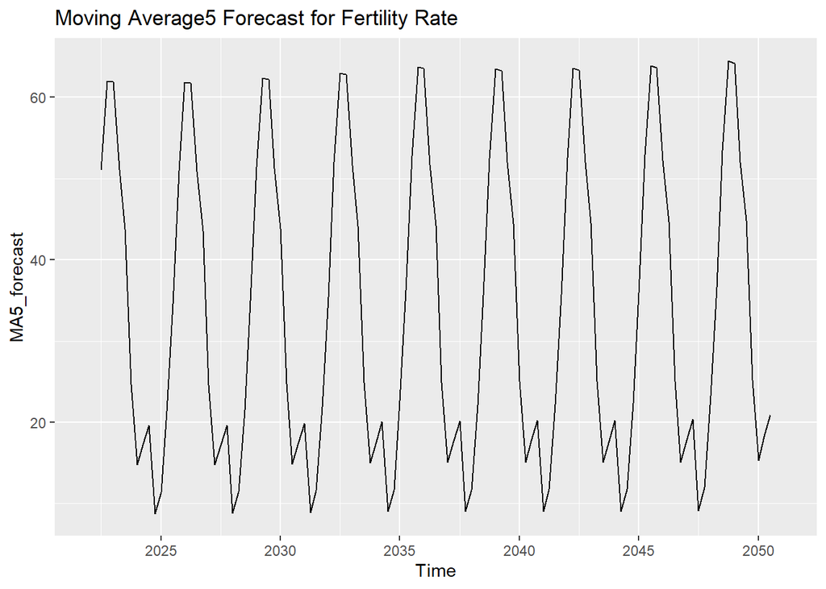

```r
#Moving Average forecast
MA5_forecast <- ma(ts_data,order=5)
# Plot the forecast
autoplot(MA5_forecast) + ggtitle("Moving Average5 Forecast for Fertility Rate")
```

```r
forecast(MA5_forecast)
```

```
##         Point Forecast       Lo 80     Hi 80       Lo 95     Hi 95
## 2050 Q4       23.05186  11.2814558  34.82227    5.050578  41.05315
## 2051 Q1       24.74401   0.8156543  48.67236  -11.851251  61.33926
## 2051 Q2       26.09980 -10.8045069  63.00412  -30.340469  82.54008
## 2051 Q3       27.18611 -22.9348989  77.30712  -49.467359 103.83958
## 2051 Q4       28.05649 -35.1912134  91.30420  -68.672527 124.78551
## 2052 Q1       28.75387 -47.3420591 104.84980  -87.624811 145.13255
## 2052 Q2       29.31263 -59.2489194 117.87418 -106.130572 164.75583
## 2052 Q3       29.76033 -70.8316639 130.35232 -124.081847 183.60250
```

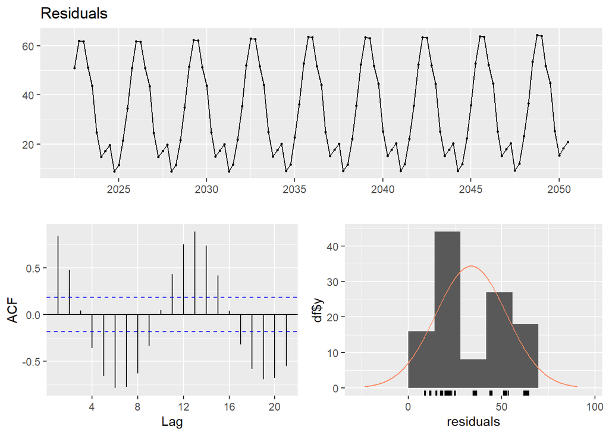

```
##
##  Ljung-Box test
##
## data:  Residuals
## Q* = 371.69, df = 8, p-value < 2.2e-16
##
## Model df: 0.   Total lags used: 8
```

```r
# Residual Analysis
checkresiduals(MA5_forecast)
```

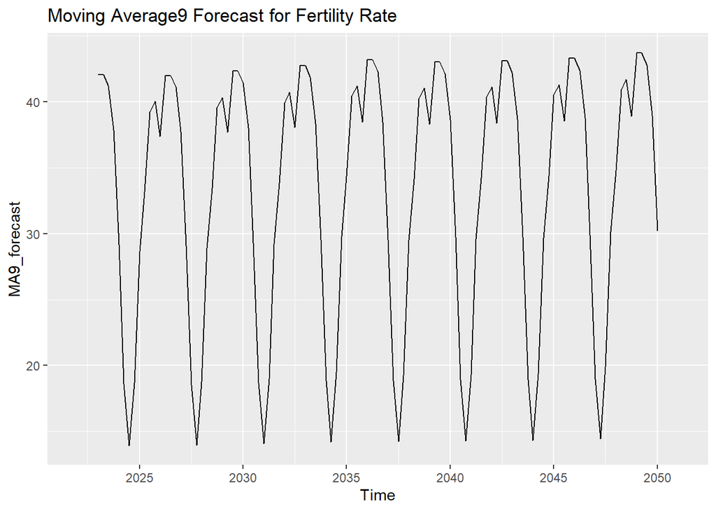

```r
#Moving Average forecast
MA9_forecast <- ma(ts_data,order=9)
# Plot the forecast
autoplot(MA9_forecast) + ggtitle("Moving Average9 Forecast for Fertility Rate")
```

```r
# Residual Analysis
forecast(MA9_forecast)
```

```
##         Point Forecast      Lo 80    Hi 80      Lo 95    Hi 95
## 2050 Q2     23.1686728  16.640107 29.69724  13.184093 33.15325
## 2050 Q3     17.4426400   4.048914 30.83637  -3.041297 37.92658
## 2050 Q4     12.7809488  -8.026512 33.58841 -19.041317 44.60321
## 2051 Q1      8.9857618 -19.439560 37.41108 -34.487017 52.45854
## 2051 Q2      5.8960154 -30.151999 41.94403 -49.234665 61.02670
## 2051 Q3      3.3805837 -40.177365 46.93853 -63.235551 69.99672
## 2051 Q4      1.3327146 -49.553654 52.21908 -76.491270 79.15670
## 2052 Q1     -0.3345013 -58.329430 57.66043 -89.030091 88.36109
```

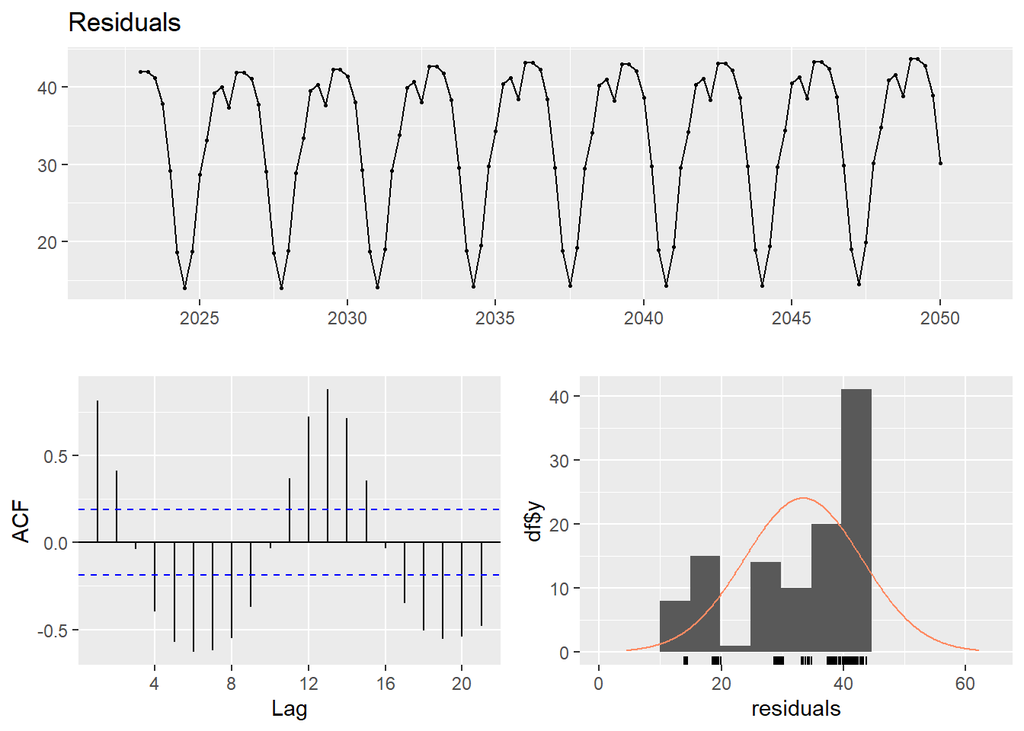

```
##
##  Ljung-Box test
##
## data:  Residuals
## Q* = 277.79, df = 8, p-value < 2.2e-16
##
## Model df: 0.   Total lags used: 8
```

```r
checkresiduals(MA9_forecast)
```

Good for smoothing and reducing noise. Does not effectively capture trend or seasonality. Significant residual lags suggest it may not fit dynamic time series with trends.

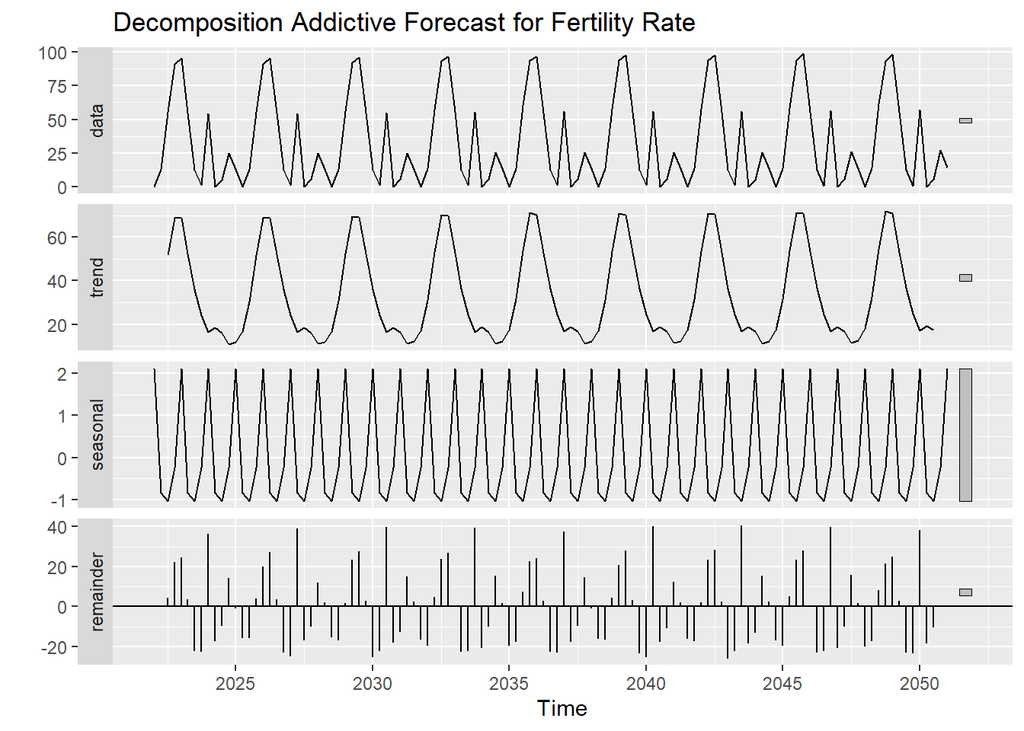

```r
##Decomposition
decomp <- decompose(ts_data, type = "additive")
# Plot the Decomposition
autoplot(decomp) + ggtitle("Decomposition Addictive Forecast for Fertility Rate")
```

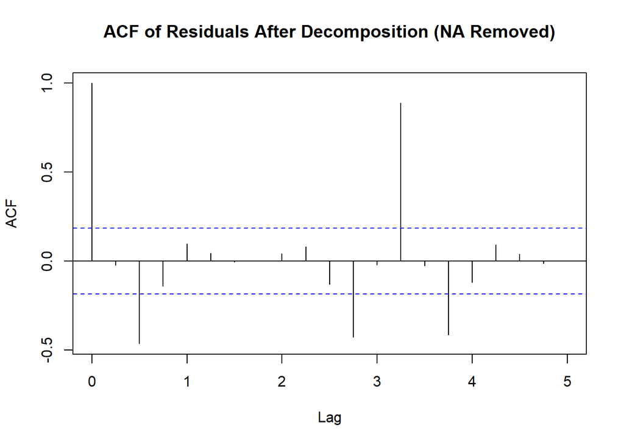

```r
residuals <- decomp$random

residuals_clean <- na.omit(residuals)

# Plot the ACF of the cleaned residuals
acf(residuals_clean, main = "ACF of Residuals After Decomposition (NA Removed)")
```

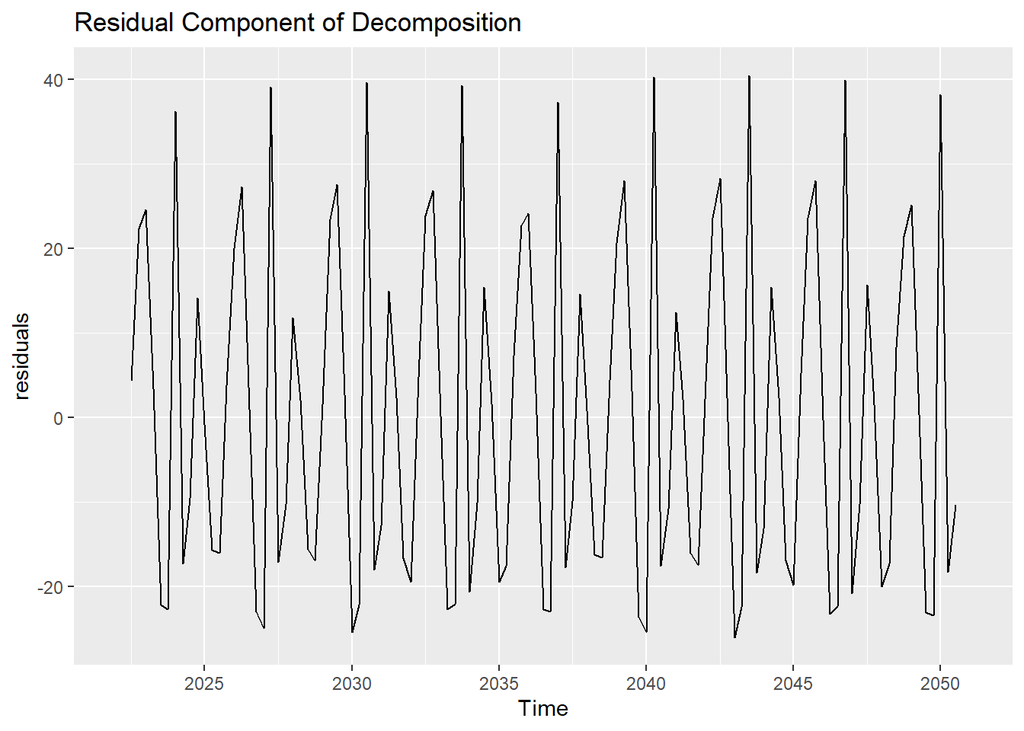

```r
# Plot the residuals
autoplot(residuals, main = "Residuals After Decomposition") + ggtitle("Residual Component of Decomposition")
```

```r
forecast(residuals_clean)
```

```
##         Point Forecast     Lo 80    Hi 80     Lo 95    Hi 95
## 2050 Q4      0.1711771 -25.72812 26.07048 -39.43838 39.78074
## 2051 Q1      0.1711771 -25.72812 26.07048 -39.43838 39.78074
## 2051 Q2      0.1711771 -25.72812 26.07048 -39.43838 39.78074
## 2051 Q3      0.1711771 -25.72812 26.07048 -39.43838 39.78074
## 2051 Q4      0.1711771 -25.72812 26.07048 -39.43838 39.78074
## 2052 Q1      0.1711771 -25.72812 26.07048 -39.43838 39.78074
## 2052 Q2      0.1711771 -25.72812 26.07048 -39.43838 39.78074
## 2052 Q3      0.1711771 -25.72812 26.07048 -39.43838 39.78074
```

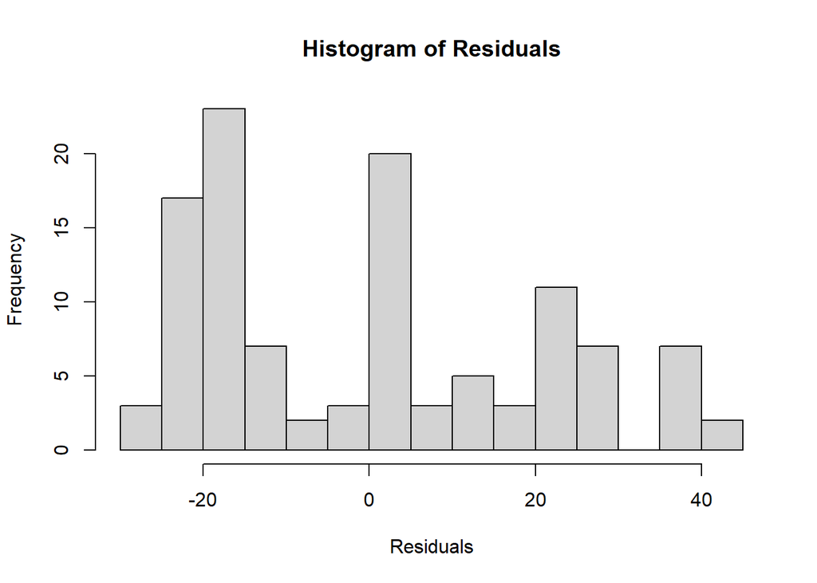

```r
# Histogram of residuals
hist(residuals, main = "Histogram of Residuals", xlab = "Residuals", breaks = 15)
```

```r
# Ljung-Box test for residuals
Box.test(residuals, lag = 10, type = "Ljung-Box")
```

```
##
##  Box-Ljung test
##
## data:  residuals
## X-squared = 32.001, df = 10, p-value = 0.0004003
```

Separates data into trend, seasonal, and residual components. Residual patterns indicate how well the model captures these components; randomness means effective decomposition.

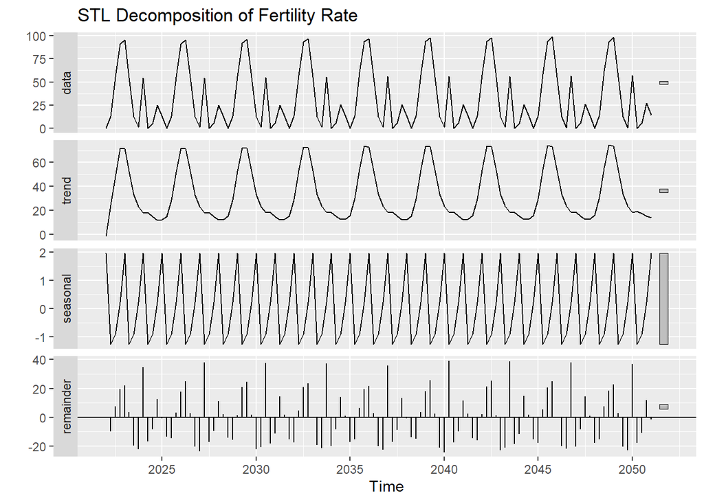

```r
# Decompose the time series
stl_decomposition <- stl(ts_data, s.window = "periodic")

# Plot the decomposition
autoplot(stl_decomposition) + ggtitle("STL Decomposition of Fertility Rate")
```

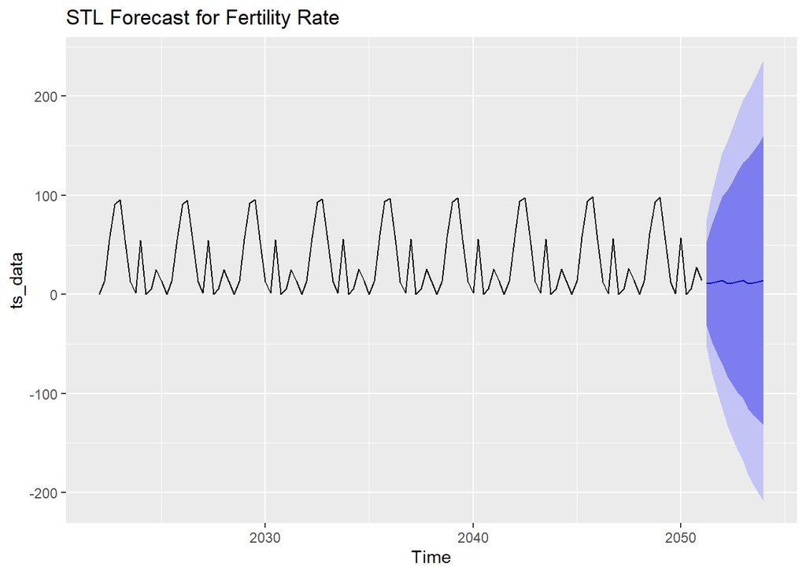

```r
# Forecast the next 12 months
stl_forecast <- forecast(stl_decomposition, h = 12)

# Plot the forecast
autoplot(stl_forecast) + ggtitle("STL Forecast for Fertility Rate")
```

```r
forecast(stl_forecast)
```

```
##         Point Forecast      Lo 80     Hi 80      Lo 95     Hi 95
## 2051 Q2       11.07495  -31.04290  53.19281  -53.33875  75.48865
## 2051 Q3       11.42814  -48.13241  70.98869  -79.66186 102.51814
## 2051 Q4       12.54713  -60.39808  85.49235  -99.01294 124.10721
## 2052 Q1       14.30152  -69.92763  98.53067 -114.51585 143.11889
## 2052 Q2       11.07495  -83.09561 105.24552 -132.94649 155.09640
## 2052 Q3       11.42814  -91.73019 114.58646 -146.33891 169.19518
## 2052 Q4       12.54713  -98.87632 123.97058 -157.86033 182.95460
## 2053 Q1       14.30152 -104.81494 133.41798 -167.87138 196.47442
## 2053 Q2       11.07495 -115.26695 137.41685 -182.14831 204.29822
## 2053 Q3       11.42814 -121.74777 144.60404 -192.24683 215.10311
## 2053 Q4       12.54713 -127.12880 152.22307 -201.06877 226.16304
## 2054 Q1       14.30152 -131.58512 160.18816 -208.81284 237.41588
```

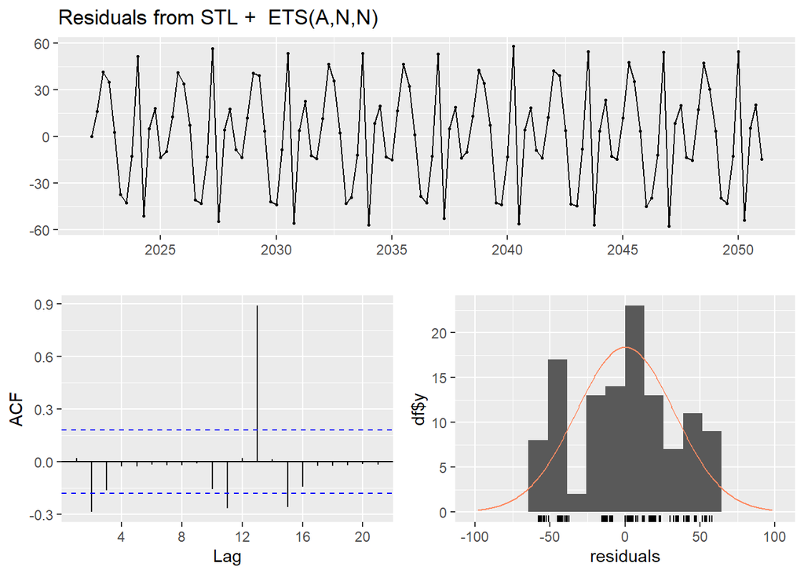

```
##
##  Ljung-Box test
##
## data:  Residuals from STL +  ETS(A,N,N)
## Q* = 13.452, df = 8, p-value = 0.09723
##
## Model df: 0.   Total lags used: 8
```

```r
# Residual Analysis
checkresiduals(stl_forecast)
```

Handles non-linear seasonality and trend effectively. Residuals should be random if both trend and seasonal components are adequately captured.

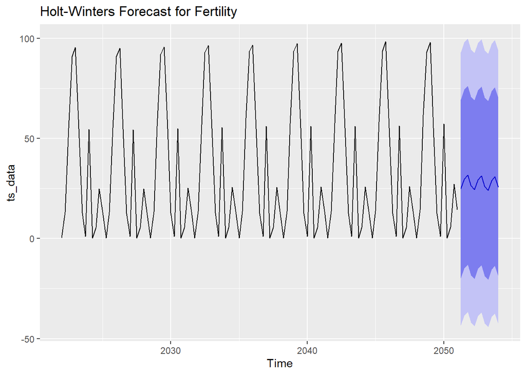

```r
# Holt-Winters Seasonal Model
hw_model <- hw(ts_data, seasonal = "additive", h = 12)

# Plot the forecast
autoplot(hw_model) + ggtitle("Holt-Winters Forecast for Fertility")
```

```r
forecast(stl_forecast)
```

```
##         Point Forecast      Lo 80     Hi 80      Lo 95     Hi 95
## 2051 Q2       11.07495  -31.04290  53.19281  -53.33875  75.48865
## 2051 Q3       11.42814  -48.13241  70.98869  -79.66186 102.51814
## 2051 Q4       12.54713  -60.39808  85.49235  -99.01294 124.10721
## 2052 Q1       14.30152  -69.92763  98.53067 -114.51585 143.11889
## 2052 Q2       11.07495  -83.09561 105.24552 -132.94649 155.09640
## 2052 Q3       11.42814  -91.73019 114.58646 -146.33891 169.19518
## 2052 Q4       12.54713  -98.87632 123.97058 -157.86033 182.95460
## 2053 Q1       14.30152 -104.81494 133.41798 -167.87138 196.47442
## 2053 Q2       11.07495 -115.26695 137.41685 -182.14831 204.29822
## 2053 Q3       11.42814 -121.74777 144.60404 -192.24683 215.10311
## 2053 Q4       12.54713 -127.12880 152.22307 -201.06877 226.16304
## 2054 Q1       14.30152 -131.58512 160.18816 -208.81284 237.41588
```

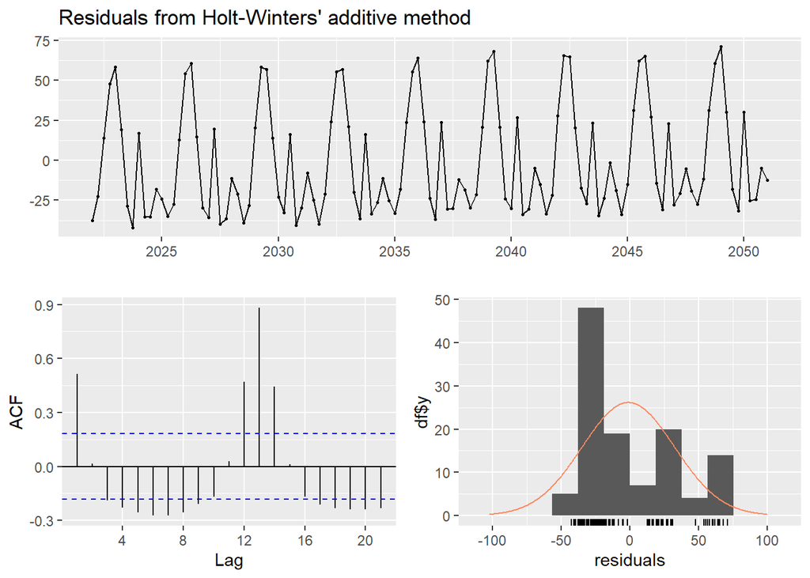

```
##
##  Ljung-Box test
##
## data:  Residuals from Holt-Winters' additive method
## Q* = 77.7, df = 8, p-value = 1.418e-13
##
## Model df: 0.   Total lags used: 8
```

```r
# Residual Analysis
checkresiduals(hw_model)
```

Captures both trend and seasonality, making it suitable for data with both components. Random residuals indicate a successful capture of underlying dynamics.

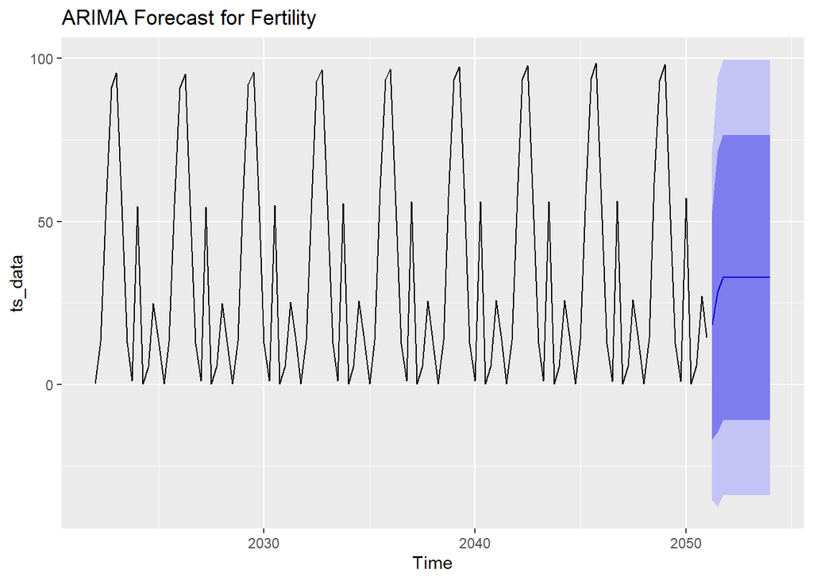

```r
# Fit an ARIMA model
arima_model <- auto.arima(ts_data)

# Forecast the next 12 months
arima_forecast <- forecast(arima_model, h = 12)

# Plot the forecast
autoplot(arima_forecast) + ggtitle("ARIMA Forecast for Fertility")
```

```r
forecast(arima_forecast)
```

```
##         Point Forecast     Lo 80    Hi 80     Lo 95    Hi 95
## 2051 Q2       18.28118 -16.87455 53.43690 -35.48486 72.04722
## 2051 Q3       28.48697 -14.56518 71.53912 -37.35561 94.32955
## 2051 Q4       32.78386 -10.85755 76.42527 -33.95992 99.52764
## 2052 Q1       32.78386 -10.85755 76.42527 -33.95992 99.52764
## 2052 Q2       32.78386 -10.85755 76.42527 -33.95992 99.52764
## 2052 Q3       32.78386 -10.85755 76.42527 -33.95992 99.52764
## 2052 Q4       32.78386 -10.85755 76.42527 -33.95992 99.52764
## 2053 Q1       32.78386 -10.85755 76.42527 -33.95992 99.52764
## 2053 Q2       32.78386 -10.85755 76.42527 -33.95992 99.52764
## 2053 Q3       32.78386 -10.85755 76.42527 -33.95992 99.52764
## 2053 Q4       32.78386 -10.85755 76.42527 -33.95992 99.52764
## 2054 Q1       32.78386 -10.85755 76.42527 -33.95992 99.52764
```

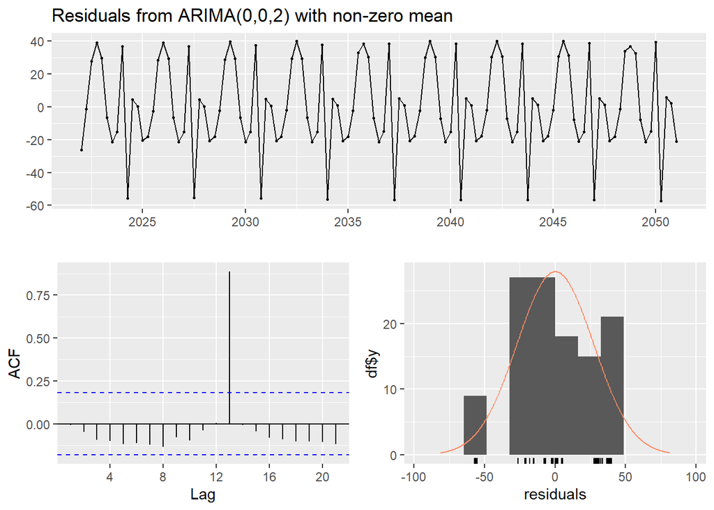

```
##
##  Ljung-Box test
##
## data:  Residuals from ARIMA(0,0,2) with non-zero mean
## Q* = 10.104, df = 6, p-value = 0.1204
##
## Model df: 2.   Total lags used: 8
```

```r
# Residual Analysis
checkresiduals(arima_model)
```

Suitable for data with auto-regressive components, differencing to make data stationary, and moving average terms. Residuals should resemble white noise without autocorrelation, indicating that the ARIMA model has properly fit the data.

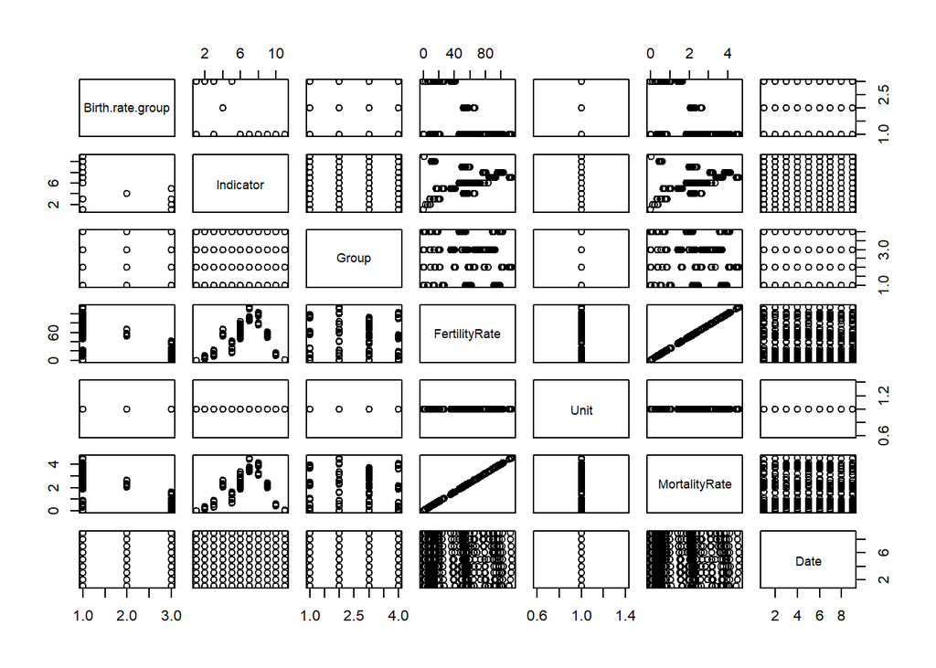

```r
#Regression Analysis

plot(data[,-1])  # Remove non-numeric columns, if necessary
```

```r
# Select only numeric columns for the pairs plot
numeric_data <- data[sapply(data, is.numeric)]


str(numeric_data)
```

```
## 'data.frame':    468 obs. of  2 variables:
##  $ FertilityRate: num  0.2 0.3 0.3 0.1 13.2 21.3 19.1 8.5 55.1 78.3 ...
##  $ MortalityRate: num  0.008 0.012 0.012 0.004 0.528 ...
```

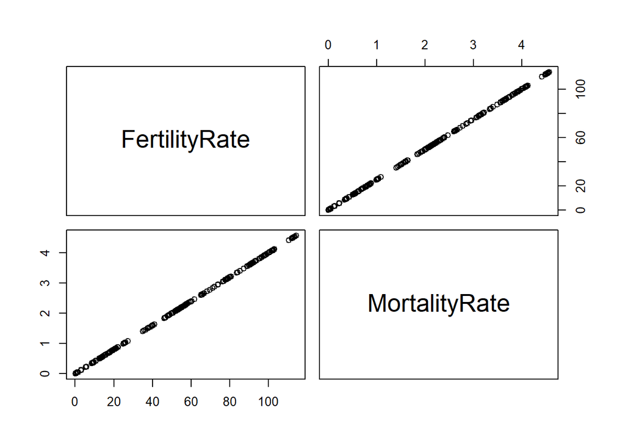

```r
# Plot pairs only if there are at least two numeric columns
if (ncol(numeric_data) > 1) {
    pairs(numeric_data)
} else {
    print("Not enough numeric columns for pairwise plot")
}
```